# Report

Luis Amigo

1 de noviembre de 2018

## Objectives

The goal of this project is just to display that you’ve gotten used to working with the data and that you are on track to create your prediction algorithm. Please submit a report on R Pubs (http://rpubs.com/) that explains your exploratory analysis and your goals for the eventual app and algorithm. This document should be concise and explain only the major features of the data you have identified and briefly summarize your plans for creating the prediction algorithm and Shiny app in a way that would be understandable to a non-data scientist manager. You should make use of tables and plots to illustrate important summaries of the data set. The motivation for this project is to: 1. Demonstrate that you’ve downloaded the data and have successfully loaded it in. 2. Create a basic report of summary statistics about the data sets. 3. Report any interesting findings that you amassed so far. 4. Get feedback on your plans for creating a prediction algorithm and Shiny app.

## File summary

We will first get a summary of file sizes:

```r
fileInformation <- function(filepath) {
  size <- file.info(filepath)$size/1048576

  conn <- file(filepath, "r")
  fulltext <- readLines(conn)
  nlines <- length(fulltext)

  maxline <- 0
  for (i in 1:nlines) {
    linelength <- nchar(fulltext[i])
    if (linelength > maxline) { maxline <- linelength }
  }
  close(conn)

  infotext <- data.frame("file"=filepath,
                     "size"= size,
                     "nlines" = nlines,
                     "maxline"=maxline)

  infotext
}

data_dir <- "./corpora/"

info <- fileInformation(paste0(data_dir,"final/en_US/en_US.blogs.txt"))
info <- rbind(info, fileInformation(paste0(data_dir,"final/en_US/en_US.news.txt")))
info <- rbind(info, fileInformation(paste0(data_dir,"final/en_US/en_US.twitter.txt")))

info
```

```
##                                      file     size  nlines maxline
## 1   ./corpora/final/en_US/en_US.blogs.txt 200.4242  899288   40835
## 2    ./corpora/final/en_US/en_US.news.txt 196.2366 1010242   11384
## 3 ./corpora/final/en_US/en_US.twitter.txt 159.3641 2360148     213
```

So we have a combined size of:

```r
paste0(sprintf("%.2f",sum(info$size))," MB")
```

```
## [1] "556.02 MB"
```

And a combined number of lines:

```r
sum(info$nlines)
```

```
## [1] 4269678
```

## Preparing data

We extract a subset of lines from each file to contruct a data frame for observation purposes. Before creating algorithm We will extract all data of the files following this procedure but not limiting the number of lines so we can make the relevant subsets.

Data needs to be cleaned before using it, specially twitter content:

```r
nlines <- 100000
regex <- "[^a-zA-Z0-9]"
twitter_file <-  file("./corpora/final/en_US/en_US.twitter.txt","r")
twitter_gross <- readLines(twitter_file,nlines, encoding="UTF-8")
twitter_gross <- tolower(twitter_gross)
twitter_gross <- replace_contraction(twitter_gross)
twitter_gross <- replace_symbol(twitter_gross)
twitter_gross <- replace_abbreviation(twitter_gross)
twitter_gross <- gsub('\\p{So}|\\p{Cn}', '', twitter_gross, perl = TRUE)
twitter_gross <- cleanPosts(twitter_gross)
twitter_df <- data_frame(line=1:nlines, text=twitter_gross)
cleaned_twitter <- twitter_df[complete.cases(twitter_df), ]
twitter_words <- cleaned_twitter %>%
    unnest_tokens(word, text) %>%
    filter(str_detect(word, "[a-z']$"),
           !word %in% stop_words$word)
close(twitter_file)
twitter_words <- subset(twitter_words, grepl("\\d+",word)==FALSE)


blogs_file <-  file("./corpora/final/en_US/en_US.blogs.txt","r")
blogs_gross <- readLines(blogs_file,nlines, encoding="UTF-8")
blogs_gross <- tolower(blogs_gross)
blogs_gross <- replace_contraction(blogs_gross)
blogs_gross <- replace_symbol(blogs_gross)
blogs_gross <- replace_abbreviation(blogs_gross)
blogs_df <- data_frame(line=1:nlines, text=blogs_gross)
cleaned_blogs <- blogs_df[complete.cases(blogs_df), ]
blogs_words <- cleaned_blogs %>%
    unnest_tokens(word, text) %>%
    filter(str_detect(word, "[a-z']$"),
           !word %in% stop_words$word)
close(blogs_file)
blogs_words <- subset(blogs_words, grepl("\\d+",word)==FALSE)


news_file <-  file("./corpora/final/en_US/en_US.news.txt","r")
news_gross <- readLines(news_file,nlines, encoding="UTF-8")
news_gross <- tolower(news_gross)
news_gross <- replace_contraction(news_gross)
news_gross <- replace_symbol(news_gross)
news_gross <- replace_abbreviation(news_gross)
news_df <- data_frame(line=1:nlines, text=news_gross)
cleaned_news <- news_df[complete.cases(news_df), ]
news_words <- cleaned_news %>%
    unnest_tokens(word, text) %>%
    filter(str_detect(word, "[a-z']$"),
           !word %in% stop_words$word)
close(news_file)
news_words <- subset(news_words, grepl("\\d+",word)==FALSE)


head(news_words)
```

```
## # A tibble: 6 x 2
##    line word
##   <int> <chr>
## 1     1 home
## 2     1 apparently
## 3     2 st
## 4     2 louis
## 5     2 plant
## 6     2 close
```

## Analyzing data

We will combine all three files on a data frame but before continuing let’s analyze how different all three sources are, first of all let’s see the Tf-idf to find the most relevant terms of each source

```r
combined_words <- bind_rows(mutate(twitter_words, source = "twitter"),
                             mutate(blogs_words, source = "blogs"),
                             mutate(news_words, source = "news"))

count_words <- combined_words %>%
   count(source, word, sort = TRUE) %>%
   ungroup()

total_words <- count_words %>%
  group_by(source) %>%
  summarize(total = sum(n))

count_words <- left_join(count_words, total_words)
```

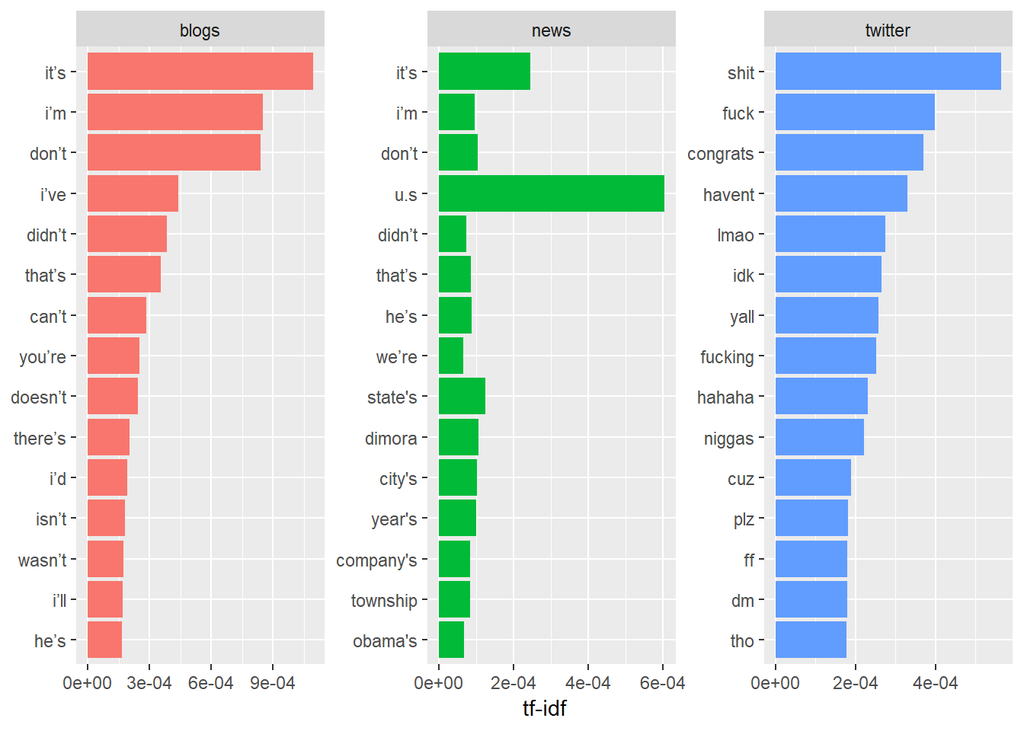

```r
count_words <- count_words %>%
  bind_tf_idf(word, source, n)

count_words %>%
  arrange(desc(tf_idf)) %>%
  mutate(word = factor(word, levels = rev(unique(word)))) %>%
  group_by(source) %>%
  top_n(15) %>%
  ungroup %>%
  ggplot(aes(word, tf_idf, fill = source)) +
  geom_col(show.legend = FALSE) +
  labs(x = NULL, y = "tf-idf") +
  facet_wrap(~source, ncol = 3, scales = "free") +
  coord_flip()
```

After that, lets see how the frequency of words compare on each source.

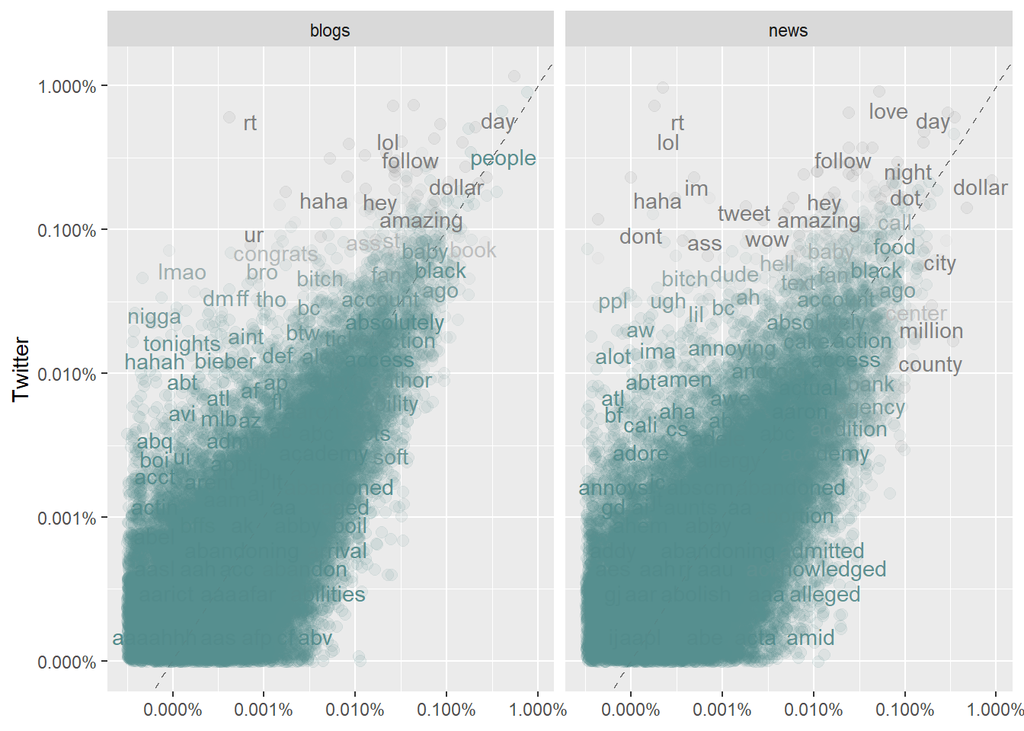

```r
word_frequency <- combined_words %>%
    count(source, word) %>%
    group_by(source) %>%
    mutate(proportion = n / sum(n)) %>%
    select(-n) %>%
    spread(source, proportion) %>%
    gather(source, proportion, `news`:`blogs`)

ggplot(word_frequency, aes(x = proportion, y = `twitter`, color = abs(`twitter` - proportion))) +
     geom_abline(color = "gray40", lty = 2) +
     geom_jitter(alpha = 0.1, size = 2.5, width = 0.3, height = 0.3) +
     geom_text(aes(label = word), check_overlap = TRUE, vjust = 1.5) +
     scale_x_log10(labels = percent_format()) +
     scale_y_log10(labels = percent_format()) +
     scale_color_gradient(limits = c(0, 0.001), low = "darkslategray4", high = "gray75") +
     facet_wrap(~source, ncol = 2) +
     theme(legend.position="none") +
     labs(y = "Twitter", x = NULL)
```

Now let’s see how data from different sources is correlated

```r
cor.test(data = word_frequency[word_frequency$source == "news",],
         ~ proportion + `twitter`)
```

```
##
##  Pearson's product-moment correlation
##
## data:  proportion and twitter
## t = 108.46, df = 28778, p-value < 2.2e-16
## alternative hypothesis: true correlation is not equal to 0
## 95 percent confidence interval:
##  0.5304137 0.5468163
## sample estimates:
##      cor
## 0.538666
```

```r
cor.test(data = word_frequency[word_frequency$source == "blogs",],
         ~ proportion + `twitter`)
```

```
##
##  Pearson's product-moment correlation
##
## data:  proportion and twitter
## t = 187.32, df = 30295, p-value < 2.2e-16
## alternative hypothesis: true correlation is not equal to 0
## 95 percent confidence interval:
##  0.7273179 0.7377530
## sample estimates:
##       cor
## 0.7325785
```

We can see how language from blogs and twitter are more similar than they are with news, which is something we intuitively could expect.

## N-Grams

At this point we have a view of how data files are built and we know they are different enough so they can add useful information, now we’ll see how do words get together studying n-grams, first we build n-gram data.frames as we built ones with words.

```r
twitter_bigrams <- cleaned_twitter %>%
    unnest_tokens(bigram, text, token = "ngrams", n = 2)
twitter_bigrams <- twitter_bigrams[complete.cases(twitter_bigrams), ]
twitter_bigrams <- subset(twitter_bigrams, grepl("\\d+",bigram)==FALSE)


news_bigrams <- cleaned_news %>%
    unnest_tokens(bigram, text, token = "ngrams", n = 2)
news_bigrams <- news_bigrams[complete.cases(news_bigrams), ]
news_bigrams <- subset(news_bigrams, grepl("\\d+",bigram)==FALSE)


blogs_bigrams <- cleaned_blogs %>%
    unnest_tokens(bigram, text, token = "ngrams", n = 2)
blogs_bigrams <- blogs_bigrams[complete.cases(blogs_bigrams), ]
blogs_bigrams <- subset(blogs_bigrams, grepl("\\d+",bigram)==FALSE)


head(news_bigrams)
```

```
## # A tibble: 6 x 2
##    line bigram
##   <int> <chr>
## 1     1 he was
## 2     1 was not
## 3     1 not home
## 4     1 home alone
## 5     1 alone apparently
## 6     2 the st
```

Now we can add all the three sources on a single bigram dataframe and check the most frequents

```r
combined_bigrams <- bind_rows(mutate(twitter_bigrams, source = "twitter"),
                             mutate(blogs_bigrams, source = "blogs"),
                             mutate(news_bigrams, source = "news"))

combined_bigrams %>%
  count(bigram, sort = TRUE)
```

```
## # A tibble: 2,312,429 x 2
##    bigram      n
##    <chr>   <int>
##  1 of the  41300
##  2 in the  37795
##  3 it is   21719
##  4 to the  19809
##  5 i am    18123
##  6 on the  17596
##  7 for the 16321
##  8 to be   14107
##  9 at the  12662
## 10 and the 12483
## # ... with 2,312,419 more rows
```

At this point we can see most common bigrams are made of stop words, we need to take it into account to estimate next word but this removes a lot useful information from our dataset so let’s take a look on how bigrams are formed when there are no stop words on the data set, we will also separate words in bigram so we can filter.

```r
bigrams_separated <- combined_bigrams %>%
  separate(bigram, c("word1", "word2"), sep = " ")

bigrams_filtered <- bigrams_separated %>%
  filter(!word1 %in% stop_words$word) %>%
  filter(!word2 %in% stop_words$word)

# new bigram counts:
bigram_counts <- bigrams_filtered %>%
  count(word1, word2, sort = TRUE)
```

Now let’s take a look to relative importance of bigrams on each source using tf-idf:

```r
bigrams_united <- bigrams_filtered %>%
  unite(bigram, word1, word2, sep = " ")

bigram_tf_idf <- bigrams_united %>%
  count(source, bigram) %>%
  bind_tf_idf(bigram, source, n) %>%
  arrange(desc(tf_idf))

bigram_tf_idf
```

```
## # A tibble: 983,862 x 6
##    source  bigram              n       tf   idf   tf_idf
##    <chr>   <chr>           <int>    <dbl> <dbl>    <dbl>
##  1 twitter rt rt              87 0.000507 1.10  0.000557
##  2 news    dr dollar         197 0.000319 1.10  0.000350
##  3 twitter lol rt             54 0.000315 1.10  0.000346
##  4 twitter happy mothers     144 0.000840 0.405 0.000341
##  5 news    st charles        155 0.000251 1.10  0.000276
##  6 twitter dollar million     39 0.000227 1.10  0.000250
##  7 news    cuyahoga county   130 0.000210 1.10  0.000231
##  8 news    gov chris         115 0.000186 1.10  0.000205
##  9 twitter rt happy           31 0.000181 1.10  0.000199
## 10 news    av dollar         105 0.000170 1.10  0.000187
## # ... with 983,852 more rows
```

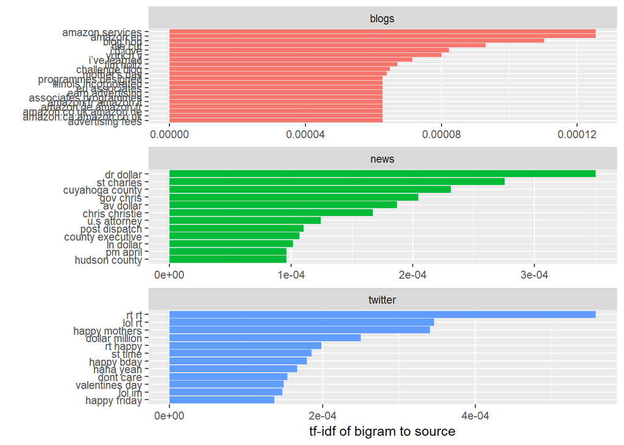

```r
bigram_tf_idf %>%
  arrange(desc(tf_idf)) %>%
  group_by(source) %>%
  top_n(12, tf_idf) %>%
  ungroup() %>%
  mutate(bigram = reorder(bigram, tf_idf)) %>%
  ggplot(aes(bigram, tf_idf, fill = source)) +
  geom_col(show.legend = FALSE) +
  facet_wrap(~ source, ncol = 1, scales = "free") +
  coord_flip() +
  labs(y = "tf-idf of bigram to source",
       x = "")
```

As a final step we will see how words correlate between them:

```r
library(widyr)

word_cors <- combined_words %>%
  group_by(word) %>%
  filter(n() >= 500) %>%
  pairwise_cor(word, source, sort = TRUE)

word_cors
```

```
## # A tibble: 1,919,610 x 3
##    item1  item2   correlation
##    <chr>  <chr>         <dbl>
##  1 shit   fuck          1.000
##  2 fuck   shit          1.000
##  3 can’t  they’re       1.000
##  4 i’m    they’re       1.000
##  5 i’d    they’re       1.000
##  6 i’ll   they’re       1.000
##  7 i’ve   they’re       1.000
##  8 that’s they’re       1.000
##  9 it’s   they’re       1.000
## 10 isn’t  they’re       1.000
## # ... with 1,919,600 more rows
```

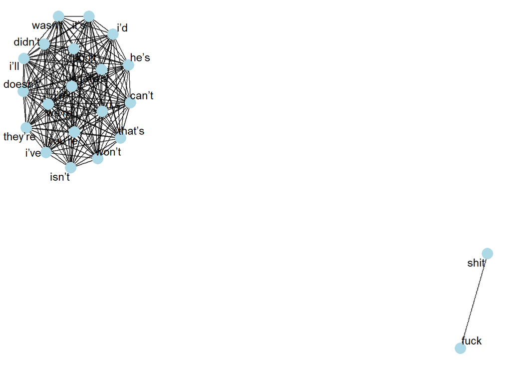

```r
word_cors %>%
  filter(correlation > .25) %>%
  graph_from_data_frame() %>%
  ggraph(layout = "fr") +
  geom_edge_link(aes(edge_alpha = correlation), show.legend = FALSE) +
  geom_node_point(color = "lightblue", size = 5) +
  geom_node_text(aes(label = name), repel = TRUE) +
  theme_void()
```

## Final Words

### Bibliography

1. [Text Mining in R](https://www.tidytextmining.com/)
2. [Today is a good day emoji code](https://github.com/today-is-a-good-day/emojis)